# 1. praktikum

09.02.2026

# Sissejuhatus

## Kursuse korraldusest

- **E** ja **K** 10.15-11.45.
- Kokku 20 kohtumist.
- Toimumisnädalad 24-25, 27-29, 31-34, 37. See tähendab, et praktikume **EI** toimu
  - 23. ja 25. veebruaril,
  - 23. ja 25. märtsil,
  - 27. ja 29. aprillil,
  - 4. ja 6. mail.
- Kohtume kohapeal. Jätame võimaluse osaleda ka Zoomi kaudu, ent praktikume ei salvestata.
- Kohalkäimine (sh virtuaalne) ei ole kohustuslik, küll aga tungivalt soovituslik.
- Kõik õppematerjalid on [Moodle](https://moodle.ut.ee/course/view.php?id=14049)’is ja sellel kursuse kodulehel.
- Kursus on arvestuslik (arvestatud/mittearvestatud).
- Arvestuse saamiseks vajalik esitada tähtajaks **kõik** kursuse jooksul antud kodutööd ja lõpuprojekt.
- 3 kodutööd:
  - Andmetüübid - tidyverse, tähtaeg **15.03.2026**.
  - Valim ja populatsioon - Mittearvuliste tunnuste vahelised seosed, tähtaeg **29.03.2026**.
  - Lineaarse regressiooni mudelid - Logistilise regressiooni segamudelid, tähtaeg **26.04.2026**.
- Lõpuprojekt: iseseisev töö, milles kasutatakse mõnd kursusel käsitletud meetodit mõnel enda valitud andmestikul. Peab sisaldama nii koodi, analüüsi kui ka järeldusi. Kokku u 5 lk. Kursuse viimasel nädalal saab enda projektist, sellega kaasnenud probleemidest jms-st lühidalt (u 5 minutit) ka teistele rääkida. Võib edasi arendada teiste ainete raames tehtud projekte, kui on selgelt välja toodud, mis analüüse olete selle aine põhjal lisanud ning kuidas need aitavad uuritavat nähtust kirjeldada ja seletada. Esitamise tähtaeg **08.05.2026**.

Selleks, et mõne nädala pärast kursuse materjalid pilla-palla kõiksugu salajastes kohtades laiali ei oleks ning et andmestike sisselugemine, jooniste salvestamine jms oleks võimalikult hõlbus, võiks kasutada selget kaustade ja failide struktuuri. Näiteks midagi sellist:

```
kvanthum2026
    /materjalid
        /praktikum1.html
        /praktikum1.Rmd
        /praktikum2.html
        /praktikum2.Rmd
        /...
    /data
        /ykstekst.txt
        /tabel12345.csv
        /andmed.RData
        /...
    /skriptid
        /praktikum1_skript.R
        /praktikum2_skript.R
        /...
    /joonised
        /joonis1.png
        /joonis2.png
    /kodutööd
        /kodutöö1
            /kodutoo1.Rmd
            /kodutoo1.html
            /kodutoo1_Perekonnanimi.Rmd
            /kodutoo1_Perekonnanimi.html
            /kodutoo1_tagasiside.txt
            /...
        /kodutöö2
        /kodutöö3
    /lõpuprojekt
```

## Lugemismaterjali

Selle kursuse aluseks on olnud põhiliselt õpikud

- Natalia Levshina (2015) “How to do Linguistics with R”,
- Bodo Winter (2019) “Statistics for Linguists: An Introduction Using R”.

[figure not shown]

[figure not shown]

Õpikuid ja ülevaateid humanitaar- ja sotsiaalteaduste meetodite kohta aga ilmub üha enam. Springeri kirjastusel näiteks on sari [*“Quantitative Methods in the Humanities and Social Sciences”*](https://www.springer.com/series/11748?detailsPage=titles), mille alt on hetkeseisuga ilmunud juba tervelt 25 raamatut.

[figure not shown]

Ajaloolasi võib huvitada ka näiteks Claire Lemercier & Claire Zalc (2019) [*“Quantitative Methods in the Humanities: An Introduction”*](https://www.upress.virginia.edu/title/5168) ja Charles H. Feinstein & Mark Thomas (2002) [*“Making History Count: A Primer in Quantitative Methods for Historians”*](https://www.cambridge.org/core/books/making-history-count/8A9D227F8ADF3BD048382D911A2C4A33).

[figure not shown]

[figure not shown]

Eestikeelseid andmeteaduse ja statistika õpikuid:

- Elena Sügis, Ardi Tampuu, Anna Aljanaki, Mark Fišel, Meelis Kull (2024) [*“Praktiline andmeteadus”*](https://courses.cs.ut.ee/t/andmeteadus/)
- Ako Sauga (2017) [*“Statistika õpik majanduseriala üliõpilastele”*](https://digikogu.taltech.ee/et/item/76e80221-4d41-40e6-b395-a6ef16609482)

[figure not shown]

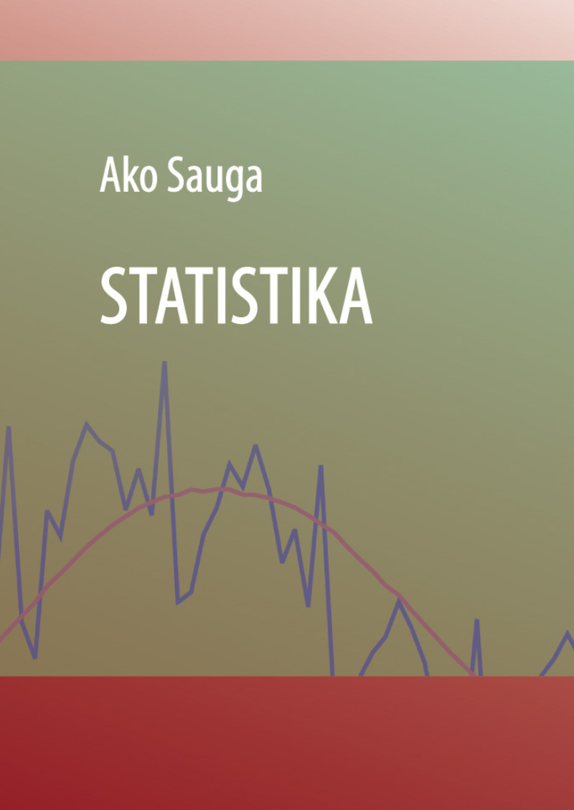

## Andmed, vaatlused ja tunnused

Hästi lihtsalt öeldes võib andmeteks pidada **teavet**, mille põhjal saab teha järeldusi.

Andmeid võib koguda mõõtmise, vaatluse, päringute või analüüsi teel. Tüüpilised andmete saamise viisid on:

- introspektsioon (?)
- intervjuu
- küsitlused
- (teksti)kogud, korpused, andmebaasid jne
- katsed
- …

[figure not shown]

Andmeid võib jagada

- toorandmeteks (“toores” allikmaterjal, nt käsikirjad, intervjuude audiosalvestised),
- töödeldud andmeteks (puhastatud, struktureeritud, märgendatud, nt märgendatud tekstid, intervjuude transkriptsioonid),
- tuletatud andmeteks (nt sagedusloendid, mudelite väljundid, visualiseeringud).

Sellel kursusel tegeleme põhiliselt küsitluste ja andmebaaside struktureeritud andmetega, mida hoitakse tabelkujul ning mille ridades olevaid **vaatlusi/andmepunkte** (ingl *observation*) iseloomustatakse teatud tulpades asuvate **tunnuste** (ingl *variable*) abil. Tabeli lahtrites omakorda on iga vaatluse iga tunnuse **väärtus** (ingl *value*).

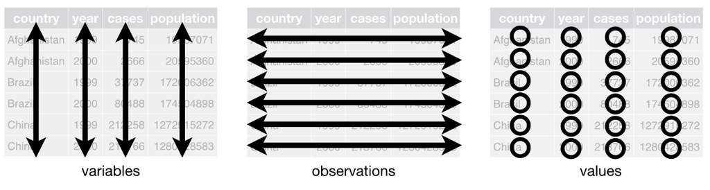

Wickham, Çetinkaya-Rundel, Grolemund (2023). [R for Data Science (2e)](https://r4ds.hadley.nz/)

Näiteks võime iseloomustada inimesi nende pikkuse, kaalu, silmavärvi, hariduse jpm tunnuste põhjal. Sõnu jällegi võib iseloomustada nende graafilise pikkuse, silpide arvu, välte, tähendusklassi, sõnaliigi, sageduse jms tunnuste põhjal.

**Milliste tunnuste põhjal võiks iseloomustada luuletusi, ohvrikive, fotosid?**

**Tunnused**/muutujad aitavad niisiis andmeid kirjeldada ja jagunevad **uuritavateks/sõltuvateks** tunnusteks (see, mida uurime ja mille kohta tahame midagi väita) ja **seletavateks/sõltumatuteks** tunnusteks (need, mille kaudu uuritavat tunnust iseloomustame). Inglise keeles viidatakse neile sageli vastavalt kui *dependent variable* / *response (variable)* / *outcome (variable)* ja *independent variable* / *predictor (variable)* / *explanatory variable*.  
Näiteks võime uuritava tunnusena käsitleda inimese kaalu ning seletavate tunnustena inimese pikkust, füüsilist aktiivsust (nt minutites nädalas), unetundide arvu jms. Sõnade puhul võib meil olla näiteks hüpotees, et sagedasemad sõnad on lühemad, mispuhul saame uuritavaks tunnuseks võtta sõna pikkuse ja seletavaks tunnuseks sõna sageduse. Kas võiks ka vastupidi?

**Mis on järgmistes näidetes uuritav ja mis seletav tunnus?**

- Kuidas mõjutavad sugu ja vanus erakondlikku eelistust?
- Kuidas sõltub teksti lugemiseks kulunud aeg lugeja sõnavara suurusest ja haridustasemest?
- Kuidas mõjutab raamatute müüginumbreid või kirjandusauhindade saamist raamatute kajastamise arv sotsiaalmeedias?
- Kuidas sõltub töötuse määrast ja sissetulekute ebavõrdsusest meeleavalduste arv?

Kui räägime kursuse kontekstis **kvantitatiivsest andmeanalüüsist**, siis

- kvantitatiivne -> arvud: mõõtmis- ja **loendusandmed**
- empiirilisus
- suurtes andmehulkades orienteerumine
- nähtuste kirjeldamine, koosesinemise mustrid ja põhjuslikud seosed
  - http://www.tylervigen.com/spurious-correlations
- sagedused, tõenäosused, varieerumise mudelid

**Kvantitatiivsete meetodite kasutamine ei asenda kvalitatiivset analüüsi ega vastandu teooriale!**  
Kvantitatiivsed meetodid humanitaarteadustes?

> *Every softer discipline these days seems to feel inadequate unless it becomes harder, more quantifiable, more scientific, more precise. That, it seems, would confer some sort of missing legitimacy in our computerized, digitized, number-happy world. But does it really? Or is it actually undermining the very heart of each discipline that falls into the trap of data, numbers, statistics, and charts? Because here’s the truth: most of these disciplines aren’t quantifiable, scientific, or precise. They are **messy and complicated**. And when you try to straighten out the tangle, you may find that you lose far more than you gain.*

> *But at the end, no matter how meticulous you’ve been, history is not a hard science. Nor is literature. Or political science. Or ethics. Or linguistics. Or psychology. Or any other number of disciplines. They don’t care about your highly involved quantitative analysis. They behave **by their own rules**.*

https://blogs.scientificamerican.com/literally-psyched/humanities-arent-a-science-stop-treating-them-like-one/

_________________________________________

> *A common prejudice, to be sure, divides the social world into phenomena that are suitable for quantification (population distributions, social mobility, etc.) and those that are irreducibly qualitative: conversation, narratives, biography, ethnography, and history often serve as examples. **Formalisms clearly can and do apply, however, to these phenomena as well**.* ([Tilly 2004](https://dokumen.pub/explaining-social-processes-9781594515002-2007044656-9781594515019.html): 38)

> *Although history is not an exact science, counting, comparing, classifying, and modeling are nevertheless useful methods for **measuring our degree of doubt or certainty, making our hypotheses explicit, and evaluating the influence of a phenomenon**.* ([Lemercier, Zalc 2019](https://www.jstor.org/stable/j.ctvbqs963))

## Sellel kursusel

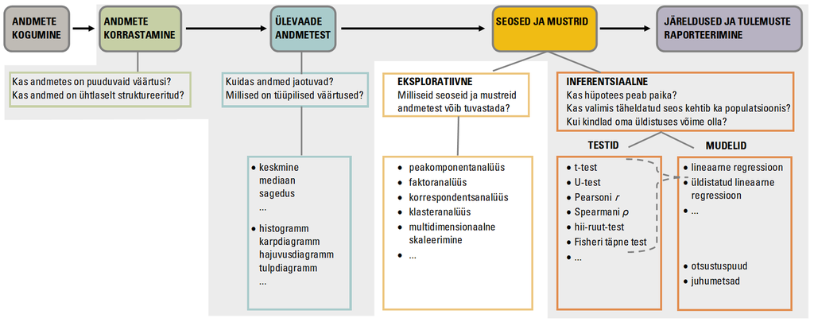

Kursusel kasutame praktikumides ja kodutöödes erinevaid andmestikke (mille valik on kohati küll tugevalt keeleteaduse poole kaldu). Selleks, et käsitletud analüüsietappe ja meetodeid veelgi paremini kinnistada, julgustame kursuse algusest peale rakendama õpitut kohe ka mõnel enda valitud andmestikul (vt ka ülesanne 1).

## Ülesanne 1

Vaata ringi erinevates [Moodle’is lingitud](https://moodle.ut.ee/mod/linkset/view.php?id=1358840) andmehoidlates ehk repositooriumides ning püüa leida mõni enda valdkonnaga seotud või enda jaoks muidu huvitav **tabelkujul** vabalt kättesaadav struktureeritud andmestik, milles **vaatlused on ridades ja tunnused tulpades**.

Vormingutest võiks eelistada TXT-, CSV-, TSV-, XLSX-laiendiga faile.

Salvesta andmestik kausta `kvanthum2026/data`.

## Miks R?

[figure not shown]

- Vabavaraline ja avatud lähtekoodiga
- Koodid taaskasutatavad ja jagatavad
- Muudab analüüsi läbipaistvaks ja korratavaks
- Võrdlemisi lihtne süntaks
- Spetsialiseerunud pigem andmeanalüüsile
- Palju erinevaid pakette ja abimaterjale
- Võimaldab kasutada väga paljusid andmeformaate
- Andmeid saab koguda, puhastada, analüüsida ja visualiseerida ühes keskkonnas (RStudio abil ka ühes programmiaknas)
- RStudio kaudu palju lisavõimalusi (slaidid, dokumendid, interaktiivsed rakendused, veebilehed)
- Integreeritav teiste keskkondade ja programmeerimiskeeltega (nt Python)

## RStudio

RStudio on R-i integreeritud arenduskeskkond (IDE), mis võimaldab mugavamalt R-iga töötada. R-i võib kasutada ka ilma RStudiota, aga RStudiot ei saa kasutada ilma R-ita.  
RStudiost on praeguseks olemas nii lokaalne, töölauaversioon, millega meie töötame, kui ka pilvepõhine, brauseris kasutatav versioon [Posit Cloud](https://posit.cloud/), mis sobib hästi lühemateks kursusteks ja kollaboratiivseks tööks.

Kasutame sel kursusel [R-i](https://www.r-project.org/) ja [RStudio](https://posit.co/download/rstudio-desktop/) viimaseid versioone (vastavalt R 4.5.2 ja RStudio 2026.01.0), ent probleemi ei tohiks tekkida ka veidi vanemate (nt viimase aasta jooksul installitud) versioonidega.

[figure not shown]

### Nippe ja trikke

- Akende paigutus: `Tools -> Global Options -> Pane Layout`
- Stiili valimine: `Tools -> Global Options -> Appearance`
- Teksti murdmine: `Tools -> Global Options -> Code -> Editing -> Soft-wrap R source files`
- Kodeeringu määramine: `Tools -> Global Options -> Code -> Saving -> Default text encoding: UTF-8`
- Töökataloogi otsimine: `getwd()`
- Töökataloogi määramine: `setwd()` või `Session -> Set Working Directory -> Choose Directory`
- Vaikimisi töökataloogi määramine: `Tools -> Global Options -> General -> Default working directory`
- Töölaua puhtana hoidmine: `Tools -> Global Options -> General -> Workspace` (eemalda linnuke)
- Pakettide installimine: `install.packages("paketinimi")`
- Pakettide laadimine: `library(paketinimi)`
- Pakettide uuendamine: `update.packages()`
- Leia konsoolis viimati kasutatud käsud: `Ctrl+Up/Down` (Windows), `Cmd+Up/Down` (Mac)
- Kontrolli R-i versiooni, lokaati, laaditud pakette: `sessionInfo()`
- Küsi abi funktsiooni kasutamiseks: `?funktsiooninimi`
- Puhasta konsool: `Ctrl+l` (Windows + Mac)
- Liigu skriptiaknasse: `Ctrl+1` (Windows + Mac)
- Liigu konsooli: `Ctrl+2` (Windows + Mac)
- Liiguta skriptis rida üles/alla: `Alt+Up/Down` (Windows), `Option+Up/Down` (Mac)
- Korda skriptis tervet rida/valikut: `Alt+Shift+Up/Down` (Windows), `Option+Cmd+Up/Down` (Mac)
- Jooksuta skriptis koodirida: `Ctrl+Enter` (Windows), `Cmd+Return` (Mac)
- Klaviatuuriklahv `Tab`
- Korrasta skriptis koodi taanded: `Ctrl+i` (Windows), `Cmd+i` (Mac)

OLULINE! Leia, kuidas klaviatuuril sisestada järgmisi sümboleid:

`<-`  
`~`  
`$`  
`^`  
`|`  
`[`  
`]`  
`{`  
`}`

## Abi

Pakettide ja nende funktsioonide kohta leiab enamasti abi R-i enda abifailidest ja dokumentatsioonist (vt ka https://www.r-project.org/help.html).

Trüki RStudio konsooliaknasse:

`help(paste)`  
`help(ggplot, package = "ggplot2")`  
`help(package = "ggplot2")`

või

`?paste`  
`?ggplot2::ggplot`

Kui sa ei tea täpselt, mis funktsiooni otsida, siis võid kasutada kaht küsimärki, et otsida enda installitud pakettidest mingit järjendit.  
`??pas`

Paketid sisaldavad enamasti ka näiteid konkreetsetest funktsioonidest.  
`example(paste)`

Samuti võib otsida pakette tutvustavaid näiteid koos seletava tekstiga.  
`browseVignettes(package = "ggplot2")`

Kõiksugu praktikas ettetulevate probleemide korral aitab kõige paremini mõistagi guugeldamine, mis viib sageli lehele [Stackoverflow](https://stackoverflow.com/questions/tagged/r).

### Abi suurtelt keelemudelitelt

Abi võib küsida põhimõtteliselt ka suurtelt keelemudelitelt (*Large Language Models* ehk LLM), nagu ChatGPT, Copilot, Claude, Llama jm. Muu hulgas on võimalik suuri keelemudeleid kasutada RStudios, näiteks paketiga [`gptstudio`](https://michelnivard.github.io/gptstudio/) (ja seda täiendava paketiga [`gpttools`](https://jameshwade.github.io/gpttools/)), [`RTutor`](https://github.com/gexijin/RTutor) või [`chattr`](https://mlverse.github.io/chattr/). Võib kasutada ka laiema funktsionaalsusega ja uuemaid mudeleid kasutada võimaldavaid pakette [`ellmer`](https://github.com/tidyverse/ellmer) või [`gander`](https://simonpcouch.github.io/gander/).

Suuri keelemudeleid saab RStudios kasutada APIde kaudu ning selleks on vaja esmalt luua vastavat keelemudelit pakkuvas keskkonnas uus API võti (*API key*) ning seadistada see RStudios. Keelemudelite kasutamine APIde kaudu võib olla tasuline.

[figure not shown]

## Ülesanne 2

Teeme joonise R-i pakettide arvust läbi aastate. Selleks kopeerime allolevas plokis oleva koodi RStudio skriptiaknasse ning jooksutame käske kas ükshaaval või korraga.

```r
# Installime vajalikud paketid
install.packages(setdiff(c("rvest", "tidyverse"), rownames(installed.packages())))

# Laadime vajalikud paketid
library(rvest)
library(tidyverse)

# Laadime alla andmestiku
url <- "https://cran.r-project.org/web/packages/available_packages_by_date.html"
paketileht <- read_html(url)
paketitabel <- html_table(paketileht)[[1]]

# Teeme joonise
paketitabel %>%
  mutate(aasta = format.Date(Date, "%Y")) %>% # teeme kuupäevast aasta
  count(aasta) %>% # loeme kokku igal aastal lisandunud paketid
  mutate(n = cumsum(n)) %>% # liidame igale aastale eelmiste aastate arvud
  ggplot(aes(x = aasta, y = n)) + # teeme ggploti joonise
  geom_col() + # tulpdiagrammina
  geom_text(aes(label = n), vjust = -0.2) # lisame ka arvud tekstina
```

Salvestame skriptifaili kursuse skriptide kausta (`File` -> `Save As`) ning joonis jooniste kausta (failide-jooniste-pakettide paneelil `Plots` -> `Export` -> `Save as Image`).

## Ülesanne 3

Määrame RStudios enda kodukataloogiks kursuse kausta (nt `kvanthum2026`). Seda võib teha kas konsoolis käsuga `setwd()`, ülamenüüs `Session` -> `Set Working Directory` -> `Choose Directory...` või paneelil `File, Plots, Packages, Help...`.

Püüame lugeda RStudiosse enda leitud andmestiku, andes sellele RStudios nime `andmestik` (`andmestik <- ...`). Kõige hõlpsam on seda teha, kasutades RStudio `Environment` jaotises (vaikimisi parem ülemine jaotis) **`Import Dataset`** tööriista. Samuti võib andmete sisselugemiseks kasutada erinevaid **`read`** käske (nt allpool), milles võib saada täpsustada näiteks, kas andmestikul on päiserida (`header`), mis sümbol eraldab tabeli välju/tulpasid (`sep`) ning mis on andmestiku kodeering (`encoding`).

```r
# CSV-failid
andmestik <- read.table("data/andmestik.csv", header = TRUE, sep = "\t", encoding = "UTF-8")
andmestik <- read.delim("data/andmestik.csv", encoding = "UTF-8")
andmestik <- read.csv("data/andmestik.csv", sep = "\t", encoding = "UTF-8")
andmestik <- read.csv2("data/andmestik.csv", sep = "\t", encoding = "UTF-8")

# Exceli failid
install.packages("readxl")
library(readxl)
andmestik <- read_excel("data/andmestik.xlsx")

# SPSSi, SASi, STATA failid
install.packages("haven")
library(haven)
andmestik <- read_sav("data/andmestik.sav") # SPSS
andmestik <- read_sas("data/andmestik.sas7bdat") # SAS
andmestik <- read_stata("data/andmestik.dta") # STATA

# JSONi failid
install.packages("jsonlite")
library(jsonlite)
andmestik <- fromJSON("data/andmestik.json")

# XMLi failid
install.packages("xml2")
library(xml2)
andmestik <- as.data.frame(read_xml("data/andmestik.xml"))
```

Veel üks hõlbus viis andmeid R-i lugeda on teha kogu andmefaili sisu aktiivseks, kopeerida kogu andmestik (Win `Ctrl+C`) ning kasutada seejärel käsku **`read.delim()`**, mille sulgude sees ütleb **“clipboard”**, et andmed loetakse lõikepuhvrist, ning argumendiga `sep` tuleb öelda, mis sümbolit kasutatakse väljade/tulpade eraldamiseks (nt kas koma `,`, tabeldusklavhi ehk tabulaatorit `\t`, semikoolonit `;`, tühikut vm-d). Selline andmestiku R-i lugemine ei ole aga väga hästi korratav, kuna sel juhul ei jää skripti ega koodilogidesse jälge sellest, millist faili on sisse loetud.

```r
andmestik <- read.delim("clipboard", sep = ",") # loeme lõikepuhvrist tabeli, milles tulpasid eraldab koma
```

Kui sul ei õnnestunud praegu ühtki sobivat andmestikku leida, siis kasuta etteantud faili `Pilot_Est_Aus.csv`. Andmestikus on andmed pilootuuringust ([Põder & Tammets 2025](https://zenodo.org/records/15401669)), milles taheti teada saada, kuidas erinevad koolitussekkumised mõjutavad Eesti ja Austria õpetajate usku oma võimesse kasutada digivahendeid tõhusalt õppetöös. Uuring põhineb enne–pärast mõõtmisega küsitlusel ning sisaldab enesetõhususe, koolituse kognitiivse aktiveerivuse ja osalejate taustatunnuste mõõdikuid.

```r
andmestik <- read.csv("data/Pilot_Est_Aus.csv")
```

Loome kiire ülevaate andmestiku tunnustest ja nende jaotumisest.

```r
# Installime vajalikud paketid
# Siin teeme esmalt loendi vajaminevatest pakettidest
# ning seejärel installime paketid ainult juhul, kui need ei ole veel juba installitud pakettide nimekirjas
install.packages(setdiff(c("Hmisc", "esquisse"), rownames(installed.packages())))

# Laadime vajalikud paketid
library(Hmisc)
library(esquisse)

# Vaatame tunnuste ülevaadet
describe(andmestik)

# Teeme mõne joonise
esquisser()
```

## Küsimustik

Täida ära küsimustik, mis asub lehel https://survey.ut.ee/index.php/347927?lang=et (aega u 5 minutit).

## R-i test

Tee Moodle’is R-i baasoskusi puudutav test. Ära muretse, kui vastata ei oska, test ei ole hindeline ega mõjuta kuidagi lõpparvestuse saamist.

## Järgmisel korral

Andmetüübid ja objektitüübid.